# MPDW Praktikum 6

## Pembentukan Model

```r
model <- Arima(
  train,
  order = c(0,1,1)
)

summary(model)
```

```
## Series: train
## ARIMA(0,1,1)
##
## Coefficients:
##           ma1
##       -0.1706
## s.e.   0.0679
##
## sigma^2 = 2469:  log likelihood = -1101.71
## AIC=2207.41   AICc=2207.47   BIC=2214.08
##
## Training set error measures:
##                    ME     RMSE      MAE        MPE      MAPE     MASE
## Training set 7.284012 49.45353 36.32879 0.04847369 0.2476956 0.970881
##                     ACF1
## Training set -0.02132586
```

## Analisis Sisaan

```r
# Sisaan Menyebar normal
ks.test(model$residuals,"pnorm")
```

```
##
##  Asymptotic one-sample Kolmogorov-Smirnov test
##
## data:  model$residuals
## D = 0.53351, p-value < 2.2e-16
## alternative hypothesis: two-sided
```

H0 : Sisaan menyebar normal H1 : Sisaan tidak menyebar normal

Berdasarkan uji KS tersebut, didapat p-value sebesar 0.00 < 0.05, maka tolak H0, sisaan pada model tidak menyebar secara normal

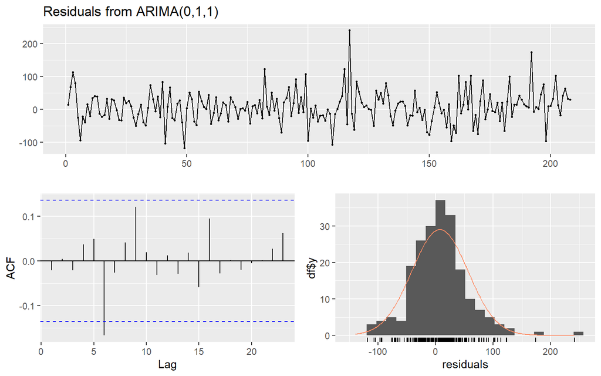

```
##
##  Ljung-Box test
##
## data:  Residuals from ARIMA(0,1,1)
## Q* = 10.891, df = 9, p-value = 0.2833
##
## Model df: 1.   Total lags used: 10
```

```r
# Sisaan Saling Bebas
checkresiduals(model)
```

Berdasakan hasil uji Ljung-Box test

H0 : Sisaan saling bebas H1 : Sisaan tidak tidak saling bebas

Dapat dilihat bahwa p-value > 0.05 yang artinya gagal tolak H0, dapat diasumsikan sisaan saling bebas

```r
# sisaan homogen
Box.test((model$residuals)^2, type = "Ljung")
```

```
##
##  Box-Ljung test
##
## data:  (model$residuals)^2
## X-squared = 0.26064, df = 1, p-value = 0.6097
```

Hipotesis yang digunakan untuk uji kehomogenan ragam adalah sebagai berikut.

H0 : Ragam sisaan homogen H1 : Ragam sisaan tidak homogen

Berdasarkan uji Ljung-Box terhadap sisaan kuadrat tersebut, didapat p-value sebesar 0.6097 > 0.05 yang menandakan ragam sisaan homogen.

# Prediksi Model

## Model Terbaik

```r
model <- Arima(
  train,
  order = c(0,1,1)
)

summary(model)
```

```
## Series: train
## ARIMA(0,1,1)
##
## Coefficients:
##           ma1
##       -0.1706
## s.e.   0.0679
##
## sigma^2 = 2469:  log likelihood = -1101.71
## AIC=2207.41   AICc=2207.47   BIC=2214.08
##
## Training set error measures:
##                    ME     RMSE      MAE        MPE      MAPE     MASE
## Training set 7.284012 49.45353 36.32879 0.04847369 0.2476956 0.970881
##                     ACF1
## Training set -0.02132586
```

## Peramalan

```r
forecast_model <- forecast(
  model,
  h = length(test)
)

forecast_model
```

```
##     Point Forecast    Lo 80    Hi 80    Lo 95    Hi 95
## 209       15461.03 15397.35 15524.72 15363.64 15558.43
## 210       15461.03 15378.29 15543.77 15334.50 15587.57
## 211       15461.03 15362.87 15559.19 15310.91 15611.16
## 212       15461.03 15349.56 15572.50 15290.55 15631.51
## 213       15461.03 15337.68 15584.39 15272.38 15649.68
## 214       15461.03 15326.85 15595.22 15255.81 15666.25
## 215       15461.03 15316.83 15605.24 15240.49 15681.58
## 216       15461.03 15307.46 15614.61 15226.16 15695.91
## 217       15461.03 15298.63 15623.44 15212.65 15709.41
## 218       15461.03 15290.25 15631.81 15199.85 15722.22
## 219       15461.03 15282.27 15639.80 15187.64 15734.43
## 220       15461.03 15274.63 15647.44 15175.95 15746.11
## 221       15461.03 15267.29 15654.78 15164.73 15757.34
## 222       15461.03 15260.22 15661.85 15153.92 15768.15
```

[output cut: 38 more lines]

## Visualisasi Forecasting

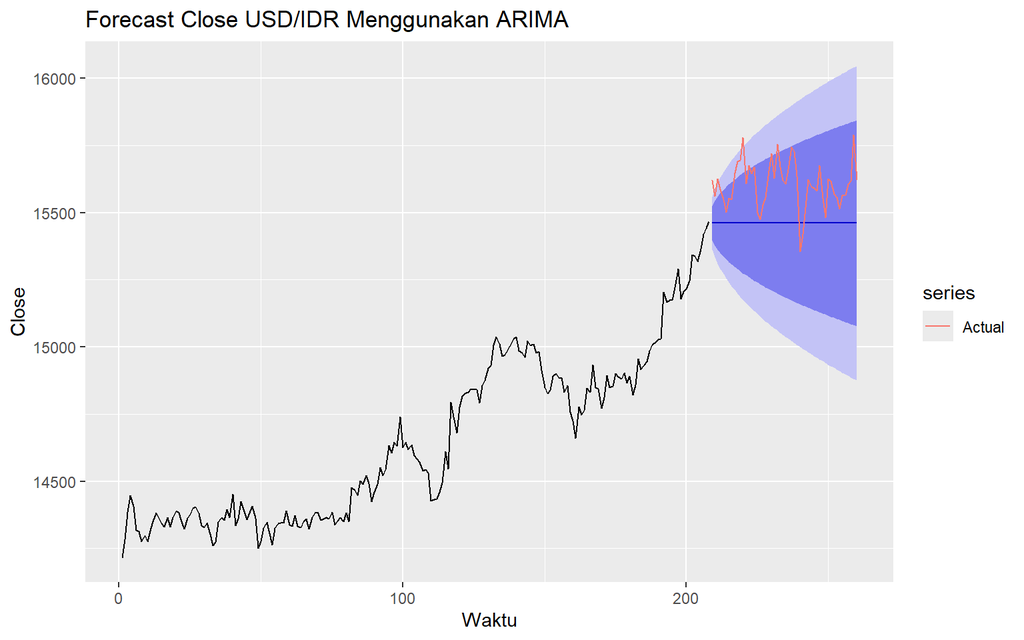

```r
autoplot(forecast_model) +
  autolayer(
    test,
    series="Actual"
  ) +
  labs(
    title="Forecast Close USD/IDR Menggunakan ARIMA",
    x="Waktu",
    y="Close"
  )
```

Berdasarkan grafik hasil peramalan menggunakan model ARIMA(0,1,1), terlihat bahwa model mampu mengikuti pola umum pergerakan harga Close USD/IDR pada periode training. Setelah periode training berakhir, model menghasilkan prediksi untuk periode testing yang ditunjukkan oleh garis forecast beserta interval kepercayaannya.

Hasil prediksi menunjukkan bahwa nilai forecast cenderung mengikuti level terakhir dari data training, yaitu berada di sekitar nilai 15.400–15.600. Hal ini sesuai dengan karakteristik model ARIMA(0,1,1) yang menggunakan komponen Moving Average (MA) untuk menangkap pola perubahan data berdasarkan error masa lalu.

## Metrik Evaluasi

```r
pred <- forecast_model$mean

MAE <- mae(
  test,
  pred
)

RMSE <- rmse(
  test,
  pred
)

MAPE <- mape(
  test,
  pred
)

data.frame(
  MAE,
  RMSE,
  MAPE
)
```

```
##        MAE    RMSE        MAPE
## 1 150.4174 168.102 0.009614271
```

Berdasarkan hasil evaluasi model ARIMA(0,1,1), diperoleh nilai Mean Absolute Error (MAE) sebesar 150.4174, yang menunjukkan bahwa rata-rata selisih absolut antara nilai aktual dan hasil peramalan adalah sekitar 150,42 poin kurs. Nilai Root Mean Square Error (RMSE) sebesar 168.102 menunjukkan besarnya tingkat kesalahan prediksi dengan memberikan penalti lebih besar terhadap kesalahan yang besar. Sementara itu, nilai Mean Absolute Percentage Error (MAPE) sebesar 0.009614271 atau sekitar 0.96% menunjukkan bahwa rata-rata kesalahan prediksi relatif terhadap nilai aktual berada di bawah 1%. Hal ini menunjukkan bahwa model ARIMA(0,1,1) mampu menghasilkan prediksi dengan tingkat kesalahan yang relatif kecil terhadap data aktual Close USD/IDR.

## Kesimpulan

Berdasarkan tahapan pemodelan deret waktu yang telah dilakukan dengan model ARIMA(0,1,1), data Close USD/IDR terlebih dahulu dibagi menjadi dua bagian, yaitu 80% data awal sebagai data training dan 20% data akhir sebagai data testing. Berdasarkan hasil identifikasi stasioneritas menggunakan uji Augmented Dickey-Fuller (ADF), data awal belum memenuhi asumsi stasioner sehingga dilakukan proses differencing satu kali. Setelah differencing, data telah memenuhi asumsi stasioner yang ditunjukkan oleh nilai p-value ADF yang lebih kecil dari taraf signifikansi 5%.

Berdasarkan pola ACF, PACF, dan EACF, diperoleh beberapa kandidat model ARIMA yang kemudian dibandingkan berdasarkan nilai AIC dan BIC. Hasil perbandingan menunjukkan bahwa model ARIMA(0,1,1) memiliki nilai AIC terkecil sehingga dipilih sebagai model terbaik. Selanjutnya dilakukan analisis residual untuk memastikan kelayakan model. Berdasarkan uji Ljung-Box, residual model telah memenuhi asumsi independensi, serta berdasarkan uji Ljung-Box terhadap residual kuadrat menunjukkan bahwa residual memiliki ragam yang homogen.